> **Tip**: Welcome to the Investigate a Dataset project! You will find tips in quoted sections like this to help organize your approach to your investigation. Once you complete this project, remove these **Tip** sections from your report before submission. First things first, you might want to double-click this Markdown cell and change the title so that it reflects your dataset and investigation.

# Project: Investigate a Dataset - TDBM Movies

- Introduction
- Data Wrangling
- Exploratory Data Analysis
- Conclusions

## Introduction

> TMDb movie data set contains information about 10,000 movies collected from The Movie Database (TMDb), including user ratings and revenue.

### Dataset Description

> Dataset contain: 10866 rows an 21 column; some of those column contains null values and there is a duplicated row.

### Question(s) for Analysis

> Question 1: How many movies were released every year?

> Question 2.1: Which movie made the highest revenue ? Question 2.2: What about the one with the lowest revenue?

> Question 3.1: Is popularity correlated with revenue? Question 3.2 Is popularity correlated with budget?

> Question 4: Is duration of movies correlated with popularity?

> Question 5: Wich genre has the highest number of movies ?

```python
# Use this cell to set up import statements for all of the packages that you
#   plan to use.

# Remember to include a 'magic word' so that your visualizations are plotted
#   inline with the notebook. See this page for more:
#   http://ipython.readthedocs.io/en/stable/interactive/magics.html


import pandas as pd
import numpy as np
import matplotlib.pyplot as plt
import seaborn as sns

%matplotlib inline
```

## Data Wrangling

> **Tip**: In this section of the report, you will load in the data, check for cleanliness, and then trim and clean your dataset for analysis. Make sure that you **document your data cleaning steps in mark-down cells precisely and justify your cleaning decisions.**

```python
# Load your data and print out a few lines. Perform operations to inspect data
#   types and look for instances of missing or possibly errant data.
df = pd.read_csv('tmdb-movies.csv')
df.head()
```

|  | id | imdb_id | popularity | budget | revenue | original_title | cast | homepage | director | tagline | ... | overview | runtime | genres | production_companies | release_date | vote_count | vote_average | release_year | budget_adj | revenue_adj |
| --- | --- | --- | --- | --- | --- | --- | --- | --- | --- | --- | --- | --- | --- | --- | --- | --- | --- | --- | --- | --- | --- |
| 0 | 135397 | tt0369610 | 32.985763 | 150000000 | 1513528810 | Jurassic World | Chris Pratt\|Bryce Dallas Howard\|Irrfan Khan\|Vi... | http://www.jurassicworld.com/ | Colin Trevorrow | The park is open. | ... | Twenty-two years after the events of Jurassic ... | 124 | Action\|Adventure\|Science Fiction\|Thriller | Universal Studios\|Amblin Entertainment\|Legenda... | 6/9/15 | 5562 | 6.5 | 2015 | 1.379999e+08 | 1.392446e+09 |
| 1 | 76341 | tt1392190 | 28.419936 | 150000000 | 378436354 | Mad Max: Fury Road | Tom Hardy\|Charlize Theron\|Hugh Keays-Byrne\|Nic... | http://www.madmaxmovie.com/ | George Miller | What a Lovely Day. | ... | An apocalyptic story set in the furthest reach... | 120 | Action\|Adventure\|Science Fiction\|Thriller | Village Roadshow Pictures\|Kennedy Miller Produ... | 5/13/15 | 6185 | 7.1 | 2015 | 1.379999e+08 | 3.481613e+08 |
| 2 | 262500 | tt2908446 | 13.112507 | 110000000 | 295238201 | Insurgent | Shailene Woodley\|Theo James\|Kate Winslet\|Ansel... | http://www.thedivergentseries.movie/#insurgent | Robert Schwentke | One Choice Can Destroy You | ... | Beatrice Prior must confront her inner demons ... | 119 | Adventure\|Science Fiction\|Thriller | Summit Entertainment\|Mandeville Films\|Red Wago... | 3/18/15 | 2480 | 6.3 | 2015 | 1.012000e+08 | 2.716190e+08 |
| 3 | 140607 | tt2488496 | 11.173104 | 200000000 | 2068178225 | Star Wars: The Force Awakens | Harrison Ford\|Mark Hamill\|Carrie Fisher\|Adam D... | http://www.starwars.com/films/star-wars-episod... | J.J. Abrams | Every generation has a story. | ... | Thirty years after defeating the Galactic Empi... | 136 | Action\|Adventure\|Science Fiction\|Fantasy | Lucasfilm\|Truenorth Productions\|Bad Robot | 12/15/15 | 5292 | 7.5 | 2015 | 1.839999e+08 | 1.902723e+09 |
| 4 | 168259 | tt2820852 | 9.335014 | 190000000 | 1506249360 | Furious 7 | Vin Diesel\|Paul Walker\|Jason Statham\|Michelle ... | http://www.furious7.com/ | James Wan | Vengeance Hits Home | ... | Deckard Shaw seeks revenge against Dominic Tor... | 137 | Action\|Crime\|Thriller | Universal Pictures\|Original Film\|Media Rights ... | 4/1/15 | 2947 | 7.3 | 2015 | 1.747999e+08 | 1.385749e+09 |

5 rows × 21 columns

```python
df.info()
```

```
<class 'pandas.core.frame.DataFrame'>
RangeIndex: 10866 entries, 0 to 10865
Data columns (total 21 columns):
id                      10866 non-null int64
imdb_id                 10856 non-null object
popularity              10866 non-null float64
budget                  10866 non-null int64
revenue                 10866 non-null int64
original_title          10866 non-null object
cast                    10790 non-null object
homepage                2936 non-null object
director                10822 non-null object
tagline                 8042 non-null object
keywords                9373 non-null object
overview                10862 non-null object
runtime                 10866 non-null int64
genres                  10843 non-null object
production_companies    9836 non-null object
release_date            10866 non-null object
vote_count              10866 non-null int64
vote_average            10866 non-null float64
release_year            10866 non-null int64
budget_adj              10866 non-null float64
revenue_adj             10866 non-null float64
dtypes: float64(4), int64(6), object(11)
memory usage: 1.7+ MB
```

```python
df.describe()
```

|  | id | popularity | budget | revenue | runtime | vote_count | vote_average | release_year | budget_adj | revenue_adj |
| --- | --- | --- | --- | --- | --- | --- | --- | --- | --- | --- |
| count | 10866.000000 | 10866.000000 | 1.086600e+04 | 1.086600e+04 | 10866.000000 | 10866.000000 | 10866.000000 | 10866.000000 | 1.086600e+04 | 1.086600e+04 |
| mean | 66064.177434 | 0.646441 | 1.462570e+07 | 3.982332e+07 | 102.070863 | 217.389748 | 5.974922 | 2001.322658 | 1.755104e+07 | 5.136436e+07 |
| std | 92130.136561 | 1.000185 | 3.091321e+07 | 1.170035e+08 | 31.381405 | 575.619058 | 0.935142 | 12.812941 | 3.430616e+07 | 1.446325e+08 |
| min | 5.000000 | 0.000065 | 0.000000e+00 | 0.000000e+00 | 0.000000 | 10.000000 | 1.500000 | 1960.000000 | 0.000000e+00 | 0.000000e+00 |
| 25% | 10596.250000 | 0.207583 | 0.000000e+00 | 0.000000e+00 | 90.000000 | 17.000000 | 5.400000 | 1995.000000 | 0.000000e+00 | 0.000000e+00 |
| 50% | 20669.000000 | 0.383856 | 0.000000e+00 | 0.000000e+00 | 99.000000 | 38.000000 | 6.000000 | 2006.000000 | 0.000000e+00 | 0.000000e+00 |
| 75% | 75610.000000 | 0.713817 | 1.500000e+07 | 2.400000e+07 | 111.000000 | 145.750000 | 6.600000 | 2011.000000 | 2.085325e+07 | 3.369710e+07 |
| max | 417859.000000 | 32.985763 | 4.250000e+08 | 2.781506e+09 | 900.000000 | 9767.000000 | 9.200000 | 2015.000000 | 4.250000e+08 | 2.827124e+09 |

```python
df.shape
```

```
(10866, 21)
```

```python
#sum null values to know how many nulls we have fo each column

df.isnull().sum()
```

```
id                         0
imdb_id                   10
popularity                 0
budget                     0
revenue                    0
original_title             0
cast                      76
homepage                7930
director                  44
tagline                 2824
keywords                1493
overview                   4
runtime                    0
genres                    23
production_companies    1030
release_date               0
vote_count                 0
vote_average               0
release_year               0
budget_adj                 0
revenue_adj                0
dtype: int64
```

There are a lot of columns with missing values!

**Filling null values with fillna-method**

> I choose this method to not drop a lot of rows that will be important for the analysis

```python
#Filling null value with 0

DF = df.fillna(0)
```

```python
#check if it worked
DF.isnull().sum()
```

```
id                      0
imdb_id                 0
popularity              0
budget                  0
revenue                 0
original_title          0
cast                    0
homepage                0
director                0
tagline                 0
keywords                0
overview                0
runtime                 0
genres                  0
production_companies    0
release_date            0
vote_count              0
vote_average            0
release_year            0
budget_adj              0
revenue_adj             0
dtype: int64
```

### Data Cleaning

```python
# After discussing the structure of the data and any problems that need to be
#   cleaned, perform those cleaning steps in the second part of this section.
```

> **Removing duplicate rows from Dataset**

```python
#Count the duplicates

DF.duplicated().sum()
```

```
1
```

```python
#Deleting the duplicated rows

DF.drop_duplicates(inplace=True)
```

```python
DF.shape
```

```
(10865, 21)
```

> **Removing columns that will not be used for analysis**

```python
#Drop the columns that are not needed
DF.drop(['imdb_id','homepage','tagline','overview','budget_adj','revenue_adj','keywords'], axis=1, inplace = True)
```

```python
DF.head()
```

|  | id | popularity | budget | revenue | original_title | cast | director | runtime | genres | production_companies | release_date | vote_count | vote_average | release_year |
| --- | --- | --- | --- | --- | --- | --- | --- | --- | --- | --- | --- | --- | --- | --- |
| 0 | 135397 | 32.985763 | 150000000 | 1513528810 | Jurassic World | Chris Pratt\|Bryce Dallas Howard\|Irrfan Khan\|Vi... | Colin Trevorrow | 124 | Action\|Adventure\|Science Fiction\|Thriller | Universal Studios\|Amblin Entertainment\|Legenda... | 6/9/15 | 5562 | 6.5 | 2015 |
| 1 | 76341 | 28.419936 | 150000000 | 378436354 | Mad Max: Fury Road | Tom Hardy\|Charlize Theron\|Hugh Keays-Byrne\|Nic... | George Miller | 120 | Action\|Adventure\|Science Fiction\|Thriller | Village Roadshow Pictures\|Kennedy Miller Produ... | 5/13/15 | 6185 | 7.1 | 2015 |
| 2 | 262500 | 13.112507 | 110000000 | 295238201 | Insurgent | Shailene Woodley\|Theo James\|Kate Winslet\|Ansel... | Robert Schwentke | 119 | Adventure\|Science Fiction\|Thriller | Summit Entertainment\|Mandeville Films\|Red Wago... | 3/18/15 | 2480 | 6.3 | 2015 |
| 3 | 140607 | 11.173104 | 200000000 | 2068178225 | Star Wars: The Force Awakens | Harrison Ford\|Mark Hamill\|Carrie Fisher\|Adam D... | J.J. Abrams | 136 | Action\|Adventure\|Science Fiction\|Fantasy | Lucasfilm\|Truenorth Productions\|Bad Robot | 12/15/15 | 5292 | 7.5 | 2015 |
| 4 | 168259 | 9.335014 | 190000000 | 1506249360 | Furious 7 | Vin Diesel\|Paul Walker\|Jason Statham\|Michelle ... | James Wan | 137 | Action\|Crime\|Thriller | Universal Pictures\|Original Film\|Media Rights ... | 4/1/15 | 2947 | 7.3 | 2015 |

> **Format Release Date to Datetime**

```python
#change date time format

DF['release_date'] = pd.to_datetime(DF['release_date'])
```

```python
#verifying

DF['release_date'].head(2)
```

```
0   2015-06-09
1   2015-05-13
Name: release_date, dtype: datetime64[ns]
```

## Exploratory Data Analysis

> **Tip**: Now that you've trimmed and cleaned your data, you're ready to move on to exploration. **Compute statistics** and **create visualizations** with the goal of addressing the research questions that you posed in the Introduction section. You should compute the relevant statistics throughout the analysis when an inference is made about the data. Note that at least two or more kinds of plots should be created as part of the exploration, and you must compare and show trends in the varied visualizations.

### Research Question 1: How many movies were released every year?

```python
# Counting the movies released every year

year_data = DF.groupby('release_year').count()['id']
```

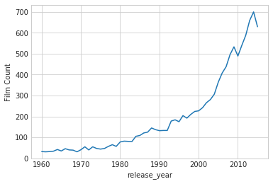

```python
# Make a line plot

year_data.plot.line()
plt.ylabel('Film Count')
sns.set_style("whitegrid");
```

### Research Question 2.1: Which movie made the highest revenue ?

```python
#finding the movie with highest revenue with .loc() and max() functions

column = DF['revenue']
max_revenue = column.max()
DF.loc[DF['revenue'] == max_revenue]
```

|  | id | popularity | budget | revenue | original_title | cast | director | runtime | genres | production_companies | release_date | vote_count | vote_average | release_year |
| --- | --- | --- | --- | --- | --- | --- | --- | --- | --- | --- | --- | --- | --- | --- |
| 1386 | 19995 | 9.432768 | 237000000 | 2781505847 | Avatar | Sam Worthington\|Zoe Saldana\|Sigourney Weaver\|S... | James Cameron | 162 | Action\|Adventure\|Fantasy\|Science Fiction | Ingenious Film Partners\|Twentieth Century Fox ... | 2009-12-10 | 8458 | 7.1 | 2009 |

**Now we know that the film with the highest revenue is Avatar with a revenue of 2'781'505'847**

### Research Question 2.2: What about the one with the lowest revenue?

```python
#finding the movie with highest revenue with .loc() and min() functions

column = DF['revenue']
min_revenue = column.min()
DF.loc[DF['revenue'] == min_revenue]
```

|  | id | popularity | budget | revenue | original_title | cast | director | runtime | genres | production_companies | release_date | vote_count | vote_average | release_year |
| --- | --- | --- | --- | --- | --- | --- | --- | --- | --- | --- | --- | --- | --- | --- |
| 48 | 265208 | 2.932340 | 30000000 | 0 | Wild Card | Jason Statham\|Michael Angarano\|Milo Ventimigli... | Simon West | 92 | Thriller\|Crime\|Drama | Current Entertainment\|Lionsgate\|Sierra / Affin... | 2015-01-14 | 481 | 5.3 | 2015 |
| 67 | 334074 | 2.331636 | 20000000 | 0 | Survivor | Pierce Brosnan\|Milla Jovovich\|Dylan McDermott\|... | James McTeigue | 96 | Crime\|Thriller\|Action | Nu Image Films\|Winkler Films\|Millennium Films\|... | 2015-05-21 | 280 | 5.4 | 2015 |
| 74 | 347096 | 2.165433 | 0 | 0 | Mythica: The Darkspore | Melanie Stone\|Kevin Sorbo\|Adam Johnson\|Jake St... | Anne K. Black | 108 | Action\|Adventure\|Fantasy | Arrowstorm Entertainment | 2015-06-24 | 27 | 5.1 | 2015 |
| 75 | 308369 | 2.141506 | 0 | 0 | Me and Earl and the Dying Girl | Thomas Mann\|RJ Cyler\|Olivia Cooke\|Connie Britt... | Alfonso Gomez-Rejon | 105 | Comedy\|Drama | Indian Paintbrush | 2015-06-12 | 569 | 7.7 | 2015 |
| 92 | 370687 | 1.876037 | 0 | 0 | Mythica: The Necromancer | Melanie Stone\|Adam Johnson\|Kevin Sorbo\|Nicola ... | A. Todd Smith | 0 | Fantasy\|Action\|Adventure | Arrowstorm Entertainment\|Camera 40 Productions... | 2015-12-19 | 11 | 5.4 | 2015 |
| 93 | 307663 | 1.872696 | 10000000 | 0 | Vice | Ambyr Childers\|Thomas Jane\|Bryan Greenberg\|Bru... | Brian A Miller | 96 | Thriller\|Science Fiction\|Action\|Adventure | Grindstone Entertainment Group\|K5 Internationa... | 2015-01-16 | 181 | 4.1 | 2015 |
| 100 | 326359 | 1.724712 | 0 | 0 | Frozen Fever | Kristen Bell\|Idina Menzel\|Jonathan Groff\|Josh ... | Chris Buck\|Jennifer Lee | 8 | Adventure\|Animation\|Family | Walt Disney Pictures\|Walt Disney Animation Stu... | 2015-03-09 | 475 | 7.0 | 2015 |
| 101 | 254302 | 1.661789 | 0 | 0 | High-Rise | Tom Hiddleston\|Sienna Miller\|Jeremy Irons\|Luke... | Ben Wheatley | 119 | Action\|Drama\|Science Fiction | Ingenious Media\|HanWay Films\|Scope Pictures\|Re... | 2015-09-26 | 161 | 5.4 | 2015 |
| 103 | 292040 | 1.646664 | 0 | 0 | Spooks: The Greater Good | Peter Firth\|Kit Harington\|Jennifer Ehle\|Lara P... | Bharat Nalluri | 104 | Thriller\|Action | BBC Films\|Isle of Man Film\|Shine Pictures\|Kudo... | 2015-04-11 | 114 | 5.6 | 2015 |
| 116 | 297291 | 1.380320 | 0 | 0 | The Scorpion King: The Lost Throne | Victor Webster\|Ellen Hollman\|Barry Bostwick\|Wi... | Mike Elliott | 105 | Action\|Fantasy\|Adventure | Universal Pictures | 2015-01-09 | 22 | 4.5 | 2015 |
| 122 | 277355 | 1.342839 | 0 | 0 | Everly | Salma Hayek\|Hiroyuki Watanabe\|Jennifer Blanc\|T... | Joe Lynch | 90 | Thriller\|Action | Crime Scene Pictures\|Radius-TWC\|Anonymous Cont... | 2015-01-23 | 169 | 5.1 | 2015 |
| 133 | 157827 | 1.251681 | 11000000 | 0 | Louder Than Bombs | Gabriel Byrne\|Isabelle Huppert\|Jesse Eisenberg... | Joachim Trier | 109 | Drama | Motlys\|Arte France Cinéma\|Animal Kingdom | 2015-05-18 | 43 | 6.3 | 2015 |
| 140 | 300803 | 1.144808 | 0 | 0 | Dragonheart 3: The Sorcerer's Curse | Julian Morris\|Tamzin Merchant\|Jassa Ahluwalia\|... | Colin Teague | 97 | Action\|Adventure\|Fantasy | Raffaella Productions | 2015-02-24 | 59 | 4.5 | 2015 |
| 143 | 378373 | 1.128081 | 0 | 0 | Brothers of the Wind | Manuel Camacho\|Jean Reno\|Tobias Moretti\|Eva Kuen | Gerado Olivares\|Otmar Penker | 98 | Adventure\|Drama\|Family | Terra Mater Factual Studios | 2015-12-24 | 11 | 7.5 | 2015 |
| 145 | 294963 | 1.073349 | 1800000 | 0 | Bone Tomahawk | Kurt Russell\|Richard Jenkins\|Matthew Fox\|Lili ... | S. Craig Zahler | 132 | Horror\|Western\|Adventure\|Drama | Caliber Media Company\|The Fyzz Facility\|Realbu... | 2015-10-23 | 220 | 6.3 | 2015 |
| 147 | 245698 | 1.063055 | 0 | 0 | Pawn Sacrifice | Tobey Maguire\|Lily Rabe\|Peter Sarsgaard\|Liev S... | Edward Zwick | 114 | Drama | Material Pictures\|MICA Entertainment\|PalmStar ... | 2015-09-16 | 148 | 6.6 | 2015 |
| 149 | 346808 | 1.041922 | 20000000 | 0 | Momentum | Olga Kurylenko\|Morgan Freeman\|James Purefoy\|Je... | Stephen S. Campanelli | 96 | Thriller\|Action | Thaba Media\|Azari Media | 2015-08-01 | 100 | 5.8 | 2015 |
| 151 | 290637 | 1.036825 | 0 | 0 | Pay the Ghost | Nicolas Cage\|Sarah Wayne Callies\|Veronica Ferr... | Uli Edel | 94 | Horror\|Thriller | Voltage Films\|Midnight Kitchen Productions | 2015-09-16 | 114 | 5.3 | 2015 |
| 152 | 244458 | 1.027620 | 0 | 0 | The Voices | Ryan Reynolds\|Gemma Arterton\|Anna Kendrick\|Jac... | Marjane Satrapi | 101 | Horror\|Thriller\|Comedy\|Crime | Studio Babelsberg\|Mandalay Vision\|1984 Private... | 2015-02-06 | 371 | 6.0 | 2015 |
| 154 | 314405 | 1.008474 | 12000000 | 0 | Il racconto dei racconti | Salma Hayek\|Vincent Cassel\|John C. Reilly\|Toby... | Matteo Garrone | 125 | Romance\|Fantasy\|Horror | HanWay Films\|Rai Cinema\|Le Pacte\|Fonds Eurimag... | 2015-05-14 | 211 | 5.7 | 2015 |
| 156 | 157843 | 0.973316 | 15000000 | 0 | Queen of the Desert | Nicole Kidman\|James Franco\|Robert Pattinson\|Da... | Werner Herzog | 128 | Drama\|History | Benaroya Pictures\|H Films\|Raslan Company of Am... | 2015-09-03 | 30 | 6.0 | 2015 |
| 158 | 290762 | 0.953647 | 0 | 0 | Miss You Already | Drew Barrymore\|Toni Collette\|Dominic Cooper\|Ja... | Catherine Hardwicke | 112 | Comedy\|Drama\|Romance | S Films\|New Sparta Films | 2015-09-12 | 139 | 7.2 | 2015 |
| 159 | 251516 | 0.953046 | 630019 | 0 | Kung Fury | David Sandberg\|Jorma Taccone\|Leopold Nilsson\|A... | David Sandberg | 31 | Action\|Comedy\|Science Fiction\|Fantasy | Laser Unicorns | 2015-05-28 | 487 | 7.7 | 2015 |
| 164 | 228968 | 0.917040 | 0 | 0 | Kidnapping Mr. Heineken | Anthony Hopkins\|Jim Sturgess\|Sam Worthington\|R... | Daniel Alfredson | 95 | Drama\|Action\|Crime\|Thriller | Umedia\|Informant Europe SPRL\|European Film Com... | 2015-03-12 | 131 | 5.8 | 2015 |
| 165 | 347969 | 0.913085 | 60000000 | 0 | The Ridiculous 6 | Adam Sandler\|Taylor Lautner\|Steve Buscemi\|Terr... | Frank Coraci | 119 | Comedy\|Western | Happy Madison Productions | 2015-12-11 | 252 | 4.8 | 2015 |
| 166 | 237756 | 0.906860 | 0 | 0 | Kill Me Three Times | Teresa Palmer\|Simon Pegg\|Luke Hemsworth\|Sulliv... | Kriv Stenders | 90 | Comedy\|Thriller | Parabolic Pictures\|Stable Way Entertainment\|Ca... | 2015-04-10 | 96 | 5.1 | 2015 |
| 169 | 311291 | 0.894477 | 0 | 0 | 45 Years | Charlotte Rampling\|Tom Courtenay\|Dolly Wells\|G... | Andrew Haigh | 95 | Drama | The Bureau | 2015-08-28 | 167 | 6.0 | 2015 |
| 174 | 342474 | 0.861179 | 0 | 0 | Jenny's Wedding | Katherine Heigl\|Tom Wilkinson\|Alexis Bledel\|Gr... | Mary Agnes Donoghue | 94 | Comedy\|Drama | MM Productions\|Merced Media Partners\|PalmStar ... | 2015-07-31 | 92 | 5.2 | 2015 |
| 175 | 277217 | 0.848748 | 0 | 0 | Descendants | Booboo Stewart\|Dove Cameron\|Keegan Connor Trac... | Kenny Ortega | 112 | Music\|Action\|Adventure\|Comedy\|Family | Walt Disney Television | 2015-07-31 | 262 | 6.7 | 2015 |
| 176 | 207936 | 0.843174 | 0 | 0 | Tumbledown | Joe Manganiello\|Jason Sudeikis\|Blythe Danner\|R... | Sean Mewshaw | 105 | Music\|Romance\|Comedy | Echo Films\|Bron Studios\|Hahnscape | 2015-04-18 | 22 | 6.6 | 2015 |
| ... | ... | ... | ... | ... | ... | ... | ... | ... | ... | ... | ... | ... | ... | ... |
| 10834 | 12639 | 0.310688 | 0 | 0 | Return of the Seven | Yul Brynner\|Robert Fuller\|Julián Mateos\|Warre... | Burt Kennedy | 95 | Action\|Western | C.B. Films S.A.\|The Mirisch Production Company | 2066-10-19 | 14 | 5.1 | 1966 |
| 10836 | 38720 | 0.239435 | 0 | 0 | Walk Don't Run | Cary Grant\|Samantha Eggar\|Jim Hutton\|John Stan... | Charles Walters | 114 | Comedy\|Romance | Columbia Pictures Corporation | 2066-01-01 | 11 | 5.8 | 1966 |
| 10837 | 19728 | 0.291704 | 0 | 0 | The Blue Max | George Peppard\|James Mason\|Ursula Andress\|Jere... | John Guillermin | 156 | War\|Action\|Adventure\|Drama | Twentieth Century Fox Film Corporation | 2066-06-21 | 12 | 5.5 | 1966 |
| 10838 | 22383 | 0.151845 | 0 | 0 | The Professionals | Burt Lancaster\|Lee Marvin\|Robert Ryan\|Woody St... | Richard Brooks | 117 | Action\|Adventure\|Western | Columbia Pictures | 2066-11-01 | 21 | 6.0 | 1966 |
| 10839 | 13353 | 0.276133 | 0 | 0 | It's the Great Pumpkin, Charlie Brown | Christopher Shea\|Sally Dryer\|Kathy Steinberg\|A... | Bill Melendez | 25 | Family\|Animation | Warner Bros. Home Video | 2066-10-27 | 49 | 7.2 | 1966 |
| 10840 | 34388 | 0.102530 | 0 | 0 | Funeral in Berlin | Michael Caine\|Paul Hubschmid\|Oskar Homolka\|Eva... | Guy Hamilton | 102 | Thriller | Lowndes Productions Limited | 2066-12-22 | 13 | 5.7 | 1966 |
| 10841 | 42701 | 0.264925 | 75000 | 0 | The Shooting | Will Hutchins\|Millie Perkins\|Jack Nicholson\|Wa... | Monte Hellman | 82 | Western | Proteus Films | 2066-10-23 | 12 | 5.5 | 1966 |
| 10842 | 36540 | 0.253437 | 0 | 0 | Winnie the Pooh and the Honey Tree | Sterling Holloway\|Junius Matthews\|Sebastian Ca... | Wolfgang Reitherman | 25 | Animation\|Family | 0 | 2066-01-01 | 12 | 7.9 | 1966 |
| 10843 | 29710 | 0.252399 | 0 | 0 | Khartoum | Charlton Heston\|Laurence Olivier\|Richard Johns... | Basil Dearden\|Eliot Elisofon | 134 | Adventure\|Drama\|War\|History\|Action | Julian Blaustein Productions Ltd. | 2066-06-09 | 12 | 5.8 | 1966 |
| 10844 | 23728 | 0.236098 | 0 | 0 | Our Man Flint | James Coburn\|Lee J. Cobb\|Gila Golan\|Edward Mul... | Daniel Mann | 108 | Adventure\|Comedy\|Fantasy\|Science Fiction | 20th Century Fox | 2066-01-16 | 13 | 5.6 | 1966 |
| 10845 | 5065 | 0.230873 | 0 | 0 | Carry On Cowboy | Sid James\|Jim Dale\|Angela Douglas\|Kenneth Will... | Gerald Thomas | 93 | Comedy\|Western | Peter Rogers Productions | 2066-03-01 | 15 | 5.9 | 1966 |
| 10846 | 17102 | 0.212716 | 0 | 0 | Dracula: Prince of Darkness | Christopher Lee\|Barbara Shelley\|Andrew Keir\|Fr... | Terence Fisher | 90 | Horror | Seven Arts Productions\|Hammer Film Productions | 2066-01-09 | 16 | 5.7 | 1966 |
| 10847 | 28763 | 0.034555 | 0 | 0 | Island of Terror | Peter Cushing\|Edward Judd\|Carole Gray\|Eddie By... | Terence Fisher | 89 | Science Fiction\|Horror | Planet Film Productions\|Protelco | 2066-06-20 | 13 | 5.3 | 1966 |
| 10849 | 28270 | 0.206537 | 0 | 0 | Gambit | Michael Caine\|Shirley MacLaine\|Herbert Lom\|Joh... | Ronald Neame | 109 | Action\|Comedy\|Crime | Universal Pictures | 2066-12-16 | 14 | 6.1 | 1966 |
| 10850 | 26268 | 0.202473 | 0 | 0 | Harper | Paul Newman\|Lauren Bacall\|Julie Harris\|Arthur ... | Jack Smight | 121 | Action\|Drama\|Thriller\|Crime\|Mystery | Warner Bros. | 2066-02-23 | 14 | 6.0 | 1966 |
| 10851 | 15347 | 0.342791 | 0 | 0 | Born Free | Virginia McKenna\|Bill Travers\|Geoffrey Keen\|Pe... | James Hill | 95 | Adventure\|Drama\|Action\|Family\|Foreign | High Road | 2066-06-22 | 15 | 6.6 | 1966 |
| 10852 | 37301 | 0.227220 | 0 | 0 | A Big Hand for the Little Lady | Henry Fonda\|Joanne Woodward\|Jason Robards\|Paul... | Fielder Cook | 95 | Western | Eden Productions Inc. | 2066-05-31 | 11 | 6.0 | 1966 |
| 10853 | 15598 | 0.163592 | 0 | 0 | Alfie | Michael Caine\|Shelley Winters\|Millicent Martin... | Lewis Gilbert | 114 | Comedy\|Drama\|Romance | 0 | 2066-03-29 | 26 | 6.2 | 1966 |
| 10854 | 31602 | 0.146402 | 0 | 0 | The Chase | Marlon Brando\|Jane Fonda\|Robert Redford\|E.G. M... | Arthur Penn | 135 | Thriller\|Drama\|Crime | Horizon Pictures\|Columbia Pictures Corporation | 2066-02-17 | 17 | 6.0 | 1966 |
| 10855 | 13343 | 0.141026 | 700000 | 0 | The Ghost & Mr. Chicken | Don Knotts\|Joan Staley\|Liam Redmond\|Dick Sarge... | Alan Rafkin | 90 | Comedy\|Family\|Mystery\|Romance | Universal Pictures | 2066-01-20 | 14 | 6.1 | 1966 |
| 10856 | 20277 | 0.140934 | 0 | 0 | The Ugly Dachshund | Dean Jones\|Suzanne Pleshette\|Charles Ruggles\|K... | Norman Tokar | 93 | Comedy\|Drama\|Family | Walt Disney Pictures | 2066-02-16 | 14 | 5.7 | 1966 |
| 10857 | 5921 | 0.131378 | 0 | 0 | Nevada Smith | Steve McQueen\|Karl Malden\|Brian Keith\|Arthur K... | Henry Hathaway | 128 | Action\|Western | Paramount Pictures\|Solar Productions\|Embassy P... | 2066-06-10 | 10 | 5.9 | 1966 |
| 10858 | 31918 | 0.317824 | 0 | 0 | The Russians Are Coming, The Russians Are Coming | Carl Reiner\|Eva Marie Saint\|Alan Arkin\|Brian K... | Norman Jewison | 126 | Comedy\|War | The Mirisch Corporation | 2066-05-25 | 11 | 5.5 | 1966 |
| 10859 | 20620 | 0.089072 | 0 | 0 | Seconds | Rock Hudson\|Salome Jens\|John Randolph\|Will Gee... | John Frankenheimer | 100 | Mystery\|Science Fiction\|Thriller\|Drama | Gibraltar Productions\|Joel Productions\|John Fr... | 2066-10-05 | 22 | 6.6 | 1966 |
| 10860 | 5060 | 0.087034 | 0 | 0 | Carry On Screaming! | Kenneth Williams\|Jim Dale\|Harry H. Corbett\|Joa... | Gerald Thomas | 87 | Comedy | Peter Rogers Productions\|Anglo-Amalgamated Fil... | 2066-05-20 | 13 | 7.0 | 1966 |
| 10861 | 21 | 0.080598 | 0 | 0 | The Endless Summer | Michael Hynson\|Robert August\|Lord 'Tally Ho' B... | Bruce Brown | 95 | Documentary | Bruce Brown Films | 2066-06-15 | 11 | 7.4 | 1966 |
| 10862 | 20379 | 0.065543 | 0 | 0 | Grand Prix | James Garner\|Eva Marie Saint\|Yves Montand\|Tosh... | John Frankenheimer | 176 | Action\|Adventure\|Drama | Cherokee Productions\|Joel Productions\|Douglas ... | 2066-12-21 | 20 | 5.7 | 1966 |
| 10863 | 39768 | 0.065141 | 0 | 0 | Beregis Avtomobilya | Innokentiy Smoktunovskiy\|Oleg Efremov\|Georgi Z... | Eldar Ryazanov | 94 | Mystery\|Comedy | Mosfilm | 2066-01-01 | 11 | 6.5 | 1966 |
| 10864 | 21449 | 0.064317 | 0 | 0 | What's Up, Tiger Lily? | Tatsuya Mihashi\|Akiko Wakabayashi\|Mie Hama\|Joh... | Woody Allen | 80 | Action\|Comedy | Benedict Pictures Corp. | 2066-11-02 | 22 | 5.4 | 1966 |
| 10865 | 22293 | 0.035919 | 19000 | 0 | Manos: The Hands of Fate | Harold P. Warren\|Tom Neyman\|John Reynolds\|Dian... | Harold P. Warren | 74 | Horror | Norm-Iris | 2066-11-15 | 15 | 1.5 | 1966 |

6016 rows × 14 columns

**Thats intresting! We found that there are about 6000 film with 0 revenues. (Note that when we filled the null values with '0', revenue column didn't have 'null' value)**

### Research Question 3.1 Is popularity correlated with revenue?

```
Correlation Between Popularity And revenue :  0.663360281413
```

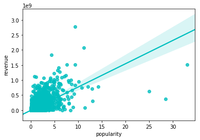

```python
#Making a plot to find the correlation between revenue and popularity

sns.regplot(x=DF['popularity'],y=DF['revenue'],color='c');
revenue_corr = DF.corr()

print("Correlation Between Popularity And revenue : ",revenue_corr.loc['popularity','revenue'])
```

> **As we can see ther is a positive correletion. Movies with high popularity tends to have high revenues (as expected).**

### Research Question 3.2 Is popularity correlated with budget?

```
Correlation Between Popularity and Budget :  0.545480792931
```

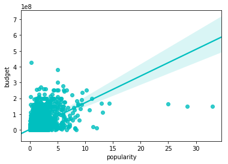

```python
#Making a plot to find the correlation between budget and popularity

sns.regplot(x=DF['popularity'],y=DF['budget'],color='c');
budget_corr = DF.corr()

print("Correlation Between Popularity and Budget : ",budget_corr.loc['popularity','budget'])
```

**There is a positive correletion between popularity and budget, but is weaker than the one between popularity and revenue.**

### Research Question 4: Is duration of movies correlated with popularity?

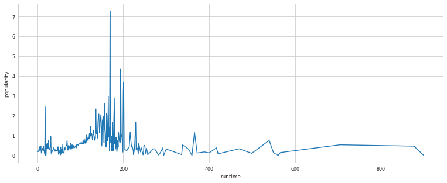

```python
DF.groupby('runtime')['popularity'].mean().plot(figsize = (13,5));
plt.xlabel('runtime')
plt.ylabel('popularity')

sns.set_style("whitegrid");
```

```
Correlation Between Popularity and Runtime :  0.139031772774
```

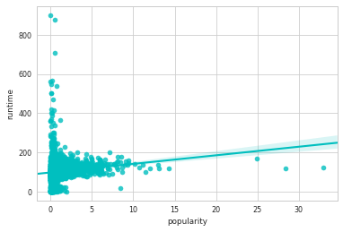

```python
#Making a plot to find the correlation between runtime and popularity


sns.regplot(x=DF['popularity'],y=DF['runtime'],color='c');
runtime_corr = DF.corr()

print("Correlation Between Popularity and Runtime : ",runtime_corr.loc['popularity','runtime'])
```

**According to the plot ther is no correlation between runtine and popularity: in fact the first plot show that the most popular movies are in a range of 100:200 minutes.**

### Research Question 5: Wich genre has the highest number of movies ?

```python
#Create a function wich splits the string and returns the count of each genre

def film_counter(x):
    #concatenate all the rows of the genres.
    data_plot = df[x].str.cat(sep = '|')
    data = pd.Series(data_plot.split('|'))
    #conts each of the genre and return.
    info = data.value_counts(ascending=False)
    return info
```

```python
total_genres = film_counter('genres')
print(total_genres)
```

```
Drama              4761
Comedy             3793
Thriller           2908
Action             2385
Romance            1712
Horror             1637
Adventure          1471
Crime              1355
Family             1231
Science Fiction    1230
Fantasy             916
Mystery             810
Animation           699
Documentary         520
Music               408
History             334
War                 270
Foreign             188
TV Movie            167
Western             165
dtype: int64
```

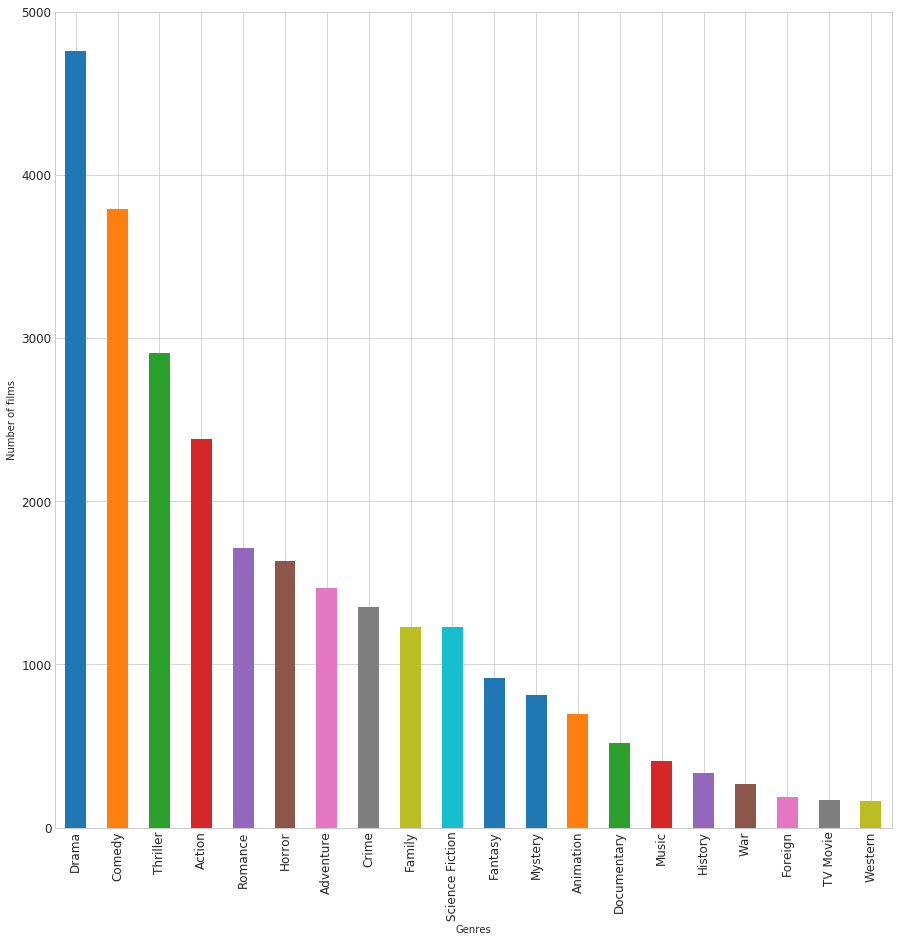

```python
#make a  bar graph to show the  number of movies released for each genre

total_genres.plot.bar(figsize =(15,15), fontsize = 12)
plt.xlabel('Genres')
plt.ylabel('Number of films')
sns.set_context('paper')
```

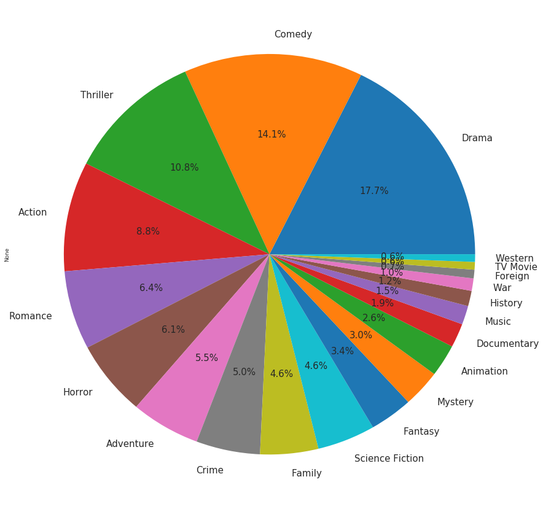

```python
#Making a pie chart to better represent the 'weight' of each genre.

total_genres.plot.pie(figsize =(15,15), fontsize = 15, autopct='%.1f%%');
```

**According to the plots, the genre with the highest release of movies is Drama (nearly 18% of the total), followed by Comedy (14.1% of the total). The genre with the lowest release of movies is Western (less then 1% of the total).**

## Conclusions

> **2)** The movie with the highest revenue is Avatar which made 2'781'505'847 dollars. There are 6016 movies that made 0 revenues.

> **3)** We found that there is a strong correlation between popularity and revenue, a weeker one between popularity and budget.

> **4)** There isn't correlation between duration and popularity. we found that the best movie duration is ranged between 100:200 minutes.

> **5)** The genre with the highest release of movies is Drama (nearly 18% of the total), followed by Comedy (14.1% of the total). The genre with the lowest release of movies is Western (less then 1% of the total).

### Limitations

We are not sure if the data provided to us is completely corect and up-to-date. The budget and revenue column do not have currency unit (Iassumed was Us Dollars), but it might be possible different movies have budget in different currency according to the country they are produce in.